# PCA

O Rodriguez de Rivera Ortega, PhD

University of Exeter

```r
##install packages
library(palmerpenguins)
library(corrr)
library(GGally)
library(recipes)
```

```r
library(tidytext)
library(dplyr)
library(tidyr)
library(ggplot2)
theme_set(theme_minimal())
```

## Correlation matrix

```r
library(corrr)
penguins_corr <- penguins %>%
  dplyr::select(where(is.numeric)) %>%
  correlate() %>%
  rearrange()
penguins_corr
```

```
## # A tibble: 5 × 6
##   term        flipper_length_mm body_mass_g bill_length_mm    year bill_depth_mm
##   <chr>                   <dbl>       <dbl>          <dbl>   <dbl>         <dbl>
## 1 flipper_le…            NA          0.871          0.656   0.170        -0.584
## 2 body_mass_g             0.871     NA              0.595   0.0422       -0.472
## 3 bill_lengt…             0.656      0.595         NA       0.0545       -0.235
## 4 year                    0.170      0.0422         0.0545 NA            -0.0604
## 5 bill_depth…            -0.584     -0.472         -0.235  -0.0604       NA
```

Body mass and flipper length appear highly correlated, but neither of the bill variables appears to be as highly correlated with any other variables.

## Pairwise plot matrix

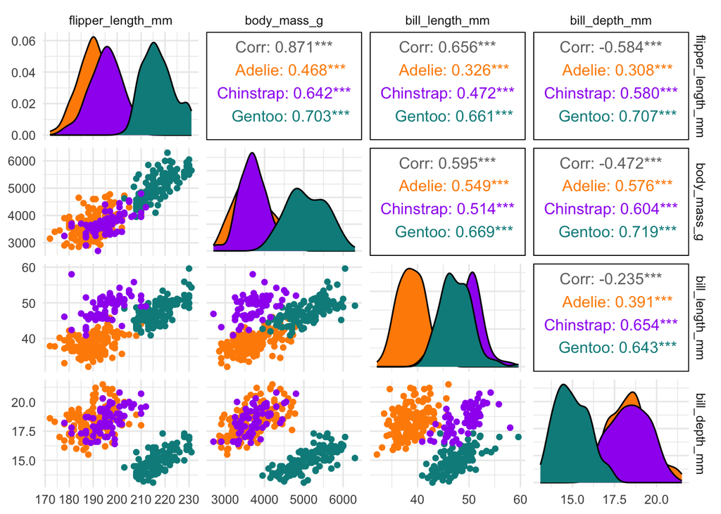

```r
penguins %>%
  select(species, where(is.numeric)) %>%
  GGally::ggpairs(aes(color = species),
          columns = c("flipper_length_mm", "body_mass_g",
                      "bill_length_mm", "bill_depth_mm")) +
  scale_colour_manual(values = c("darkorange","purple","cyan4")) +
  scale_fill_manual(values = c("darkorange","purple","cyan4"))
```

## Principal component analysis (PCA)

First, we’ll also use a few recipe steps to preprocess the data for PCA; namely, we need to:

- remove any NA values,
- center all predictors, and
- scale all predictors.

```r
library(recipes)
penguin_recipe <-
  recipe(~., data = penguins) %>%
  update_role(species, island, sex, new_role = "id") %>%
  step_naomit(all_predictors()) %>%
  step_normalize(all_predictors()) %>%
  step_pca(all_predictors(), id = "pca") %>%
  prep()

penguin_pca <-
  penguin_recipe %>%
  tidy(id = "pca")

penguin_pca
```

```
## # A tibble: 25 × 4
##    terms               value component id
##    <chr>               <dbl> <chr>     <chr>
##  1 bill_length_mm     0.452  PC1       pca
##  2 bill_depth_mm     -0.398  PC1       pca
##  3 flipper_length_mm  0.576  PC1       pca
##  4 body_mass_g        0.544  PC1       pca
##  5 year               0.0957 PC1       pca
##  6 bill_length_mm    -0.0935 PC2       pca
##  7 bill_depth_mm      0.0164 PC2       pca
##  8 flipper_length_mm  0.0256 PC2       pca
##  9 body_mass_g       -0.111  PC2       pca
## 10 year               0.989  PC2       pca
## # ℹ 15 more rows
```

The value column here is the loading. For each component, the value tells us the linear combination of weights for each variable that contributes to that component.

```r
penguins %>%
  dplyr::select(where(is.numeric)) %>%
  tidyr::drop_na() %>%
  scale() %>%
  prcomp() %>%
  .$rotation
```

```
##                           PC1         PC2          PC3          PC4        PC5
## bill_length_mm     0.45224564 -0.09346291 -0.592853269 -0.643862574  0.1438908
## bill_depth_mm     -0.39832420  0.01638435 -0.799846355  0.417714718 -0.1637975
## flipper_length_mm  0.57595238  0.02563960 -0.005357699  0.230581486 -0.7838526
## body_mass_g        0.54399668 -0.11141418 -0.078078773  0.598119608  0.5725479
## year               0.09569837  0.98890127 -0.051437436 -0.006364907  0.1011423
```

We can also examine how much variance each component accounts for:

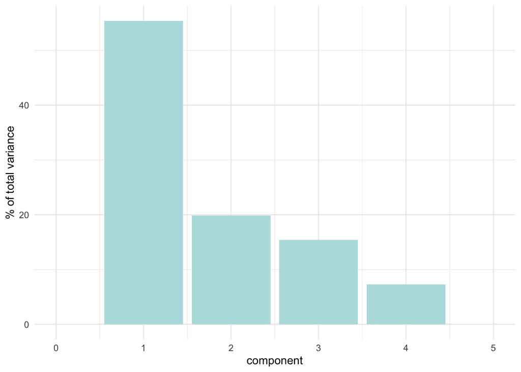

```r
penguin_recipe %>%
  tidy(id = "pca", type = "variance") %>%
  dplyr::filter(terms == "percent variance") %>%
  ggplot(aes(x = component, y = value)) +
  geom_col(fill = "#b6dfe2") +
  xlim(c(0, 5)) +
  ylab("% of total variance")
```

## Plot PCA loadings

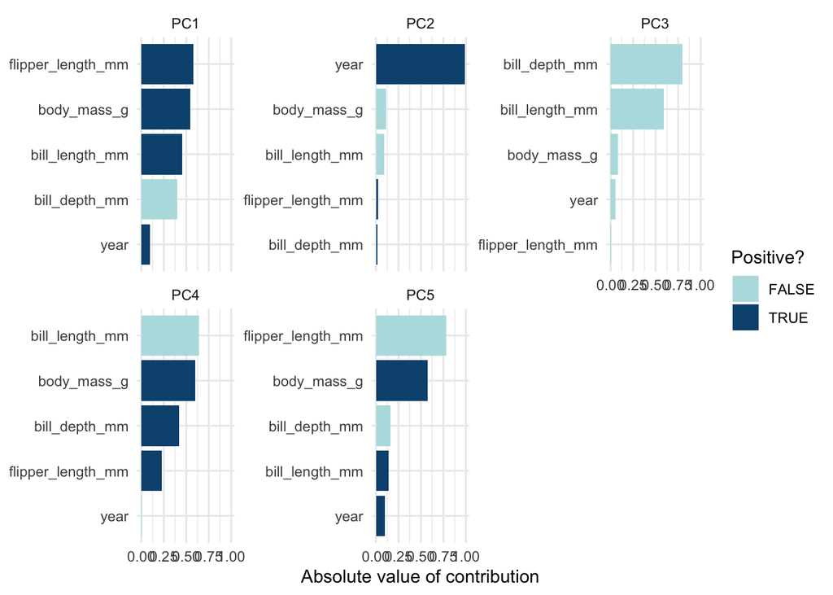

```r
library(ggplot2)
penguin_pca %>%
  mutate(terms = tidytext::reorder_within(terms,
                                          abs(value),
                                          component)) %>%
  ggplot(aes(abs(value), terms, fill = value > 0)) +
  geom_col() +
  facet_wrap(~component, scales = "free_y") +
  tidytext::scale_y_reordered() +
  scale_fill_manual(values = c("#b6dfe2", "#0A537D")) +
  labs(
    x = "Absolute value of contribution",
    y = NULL, fill = "Positive?"
  )
```

## Plot PCA loadings + scores

We have the PCA loadings in penguin_pca. But we need them in a wide format now for plotting.

# get pca loadings into wider format

```r
pca_wider <- penguin_pca %>%
  tidyr::pivot_wider(names_from = component, id_cols = terms)
```

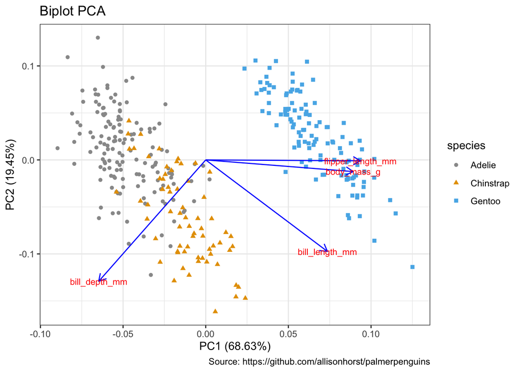

```r
library(ggfortify)
cbp1 <- c("#999999", "#E69F00", "#56B4E9", "#009E73",
          "#F0E442", "#0072B2", "#D55E00", "#CC79A7")

penguins_prep <- penguins %>%
  remove_missing() %>%
  select(bill_length_mm:body_mass_g)
penguins_pca <- penguins_prep %>%
  prcomp(scale. = TRUE)
penguins_km <- penguins_prep %>%
  kmeans(3)
autoplot(penguins_pca,
                data = penguins %>% remove_missing(),
                colour = 'species',
                shape = 'species',
                loadings = TRUE,
                loadings.colour = 'blue',
                loadings.label = TRUE,
                loadings.label.size = 3) +
      scale_color_manual(values = cbp1) +
  scale_fill_manual(values = cbp1) +
  theme_bw() +
            labs(
            title = "Biplot PCA",
            caption = "Source: https://github.com/allisonhorst/palmerpenguins")
```

First, if you focus on the x-axis showing us the first principal component, you can see that flipper length and body mass are very important (confirming what we saw in the above bar chart). Along this dimension, Gentoo penguins stand out clearly from the other two species. We can confirm this looking at summary statistics:

```r
penguins %>%
  group_by(species) %>%
  summarize(across(c(flipper_length_mm, body_mass_g),
                   mean,
                   na.rm = TRUE))
```

```
## # A tibble: 3 × 3
##   species   flipper_length_mm body_mass_g
##   <fct>                 <dbl>       <dbl>
## 1 Adelie                 190.       3701.
## 2 Chinstrap              196.       3733.
## 3 Gentoo                 217.       5076.
```

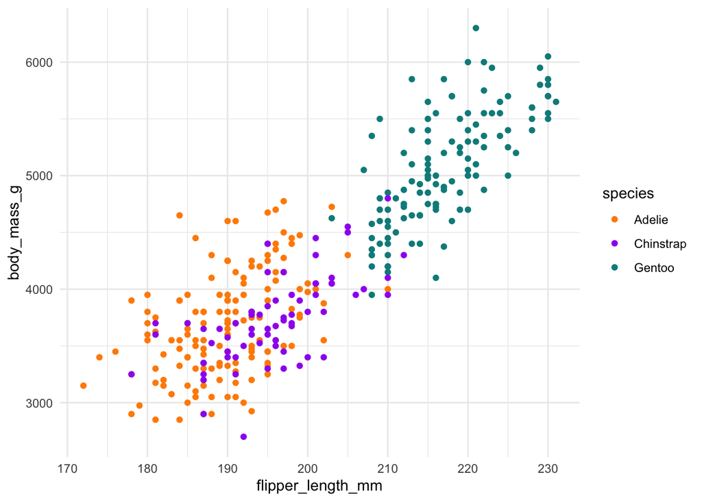

```r
ggplot(penguins, aes(x = flipper_length_mm, y = body_mass_g, colour = species)) +
  geom_point() +
  scale_colour_manual(values = c("darkorange","purple","cyan4"))
```

```r
penguins %>%
  group_by(species) %>%
  summarize(across(c(bill_depth_mm, bill_length_mm),
                   mean,
                   na.rm = TRUE))
```

```
## # A tibble: 3 × 3
##   species   bill_depth_mm bill_length_mm
##   <fct>             <dbl>          <dbl>
## 1 Adelie             18.3           38.8
## 2 Chinstrap          18.4           48.8
## 3 Gentoo             15.0           47.5
```

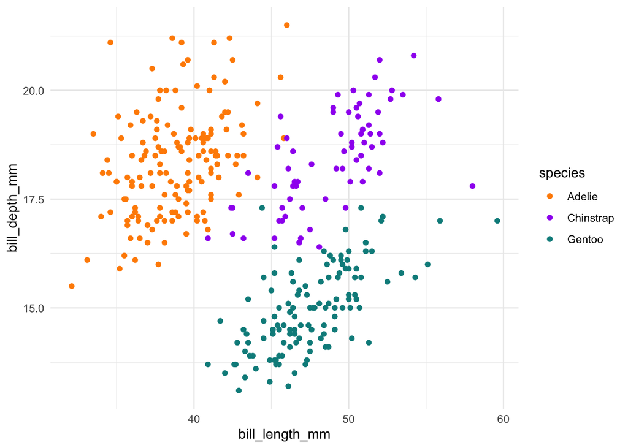

```r
ggplot(penguins, aes(x = bill_length_mm, y = bill_depth_mm, colour = species)) +
  geom_point() +
  scale_colour_manual(values = c("darkorange","purple","cyan4"))
```

This is actually a pretty neat scatterplot—it highlights a perfect example of why you’d need the combination of two variables to differentiate between these three species. Comparing distributions for any single variable only differentiates one species from the other two.